# WQD7004_GroupProject

## Group No.: 10

## Group Members

- LINGYU MENG (S2131391)
- HUIJUN LIU (S2142285)
- ZUOGE CHEN (S2125783)
- KELVIIN RAJJ KARUPAYA (S2151665)
- RUIXUE ZHANG (S2142119)

## Dataset

- Title: German Credit Risk
- Year: 2020
- Content: This dataset classifies people described by a set of attributes as good or bad credit risks.
- Source: https://www.kaggle.com/datasets/kabure/german-credit-data-with-risk
- Title: Sanction Loan
- Year: 2021
- Content: This dataset contains features related to predict the loan amount.
- Source: https://www.kaggle.com/datasets/zyper26/sanction-loan

# 1 Introduction

With rising property rates, most people avail home loans to buy their dream houses. Once you have finalized your budget and the house that you want to buy, you must ensure that you have sufficient funds to pay the seller.

Loans are the core business of banks. The main profit comes directly from the loan’s interest. The loan companies grant a loan after an intensive process of verification and validation. However, they still don’t have assurance if the applicant is able to repay the loan with no difficulties.The bank only lends up to 80% of the total amount based on a person’s finances (salary, outgoing expenses, existing loans, etc.). You will need to make the rest of the payment yourself after the bank tells you how much they can lend.

In the German Credit Risk dataset, each entry represents a person who takes a credit by a bank. Each person is classified as good or bad credit risks according to the set of attributes. In the Sanction Loan dataset, we need predict the credit risk level of applicants and the loan amount that can be sanctioned to customers who have applied for a home loan using the features provided.

## 1.1 Project Objective

- To know the relationship between applicants demographics and the credit amount.
- To predict the credit risk level of applicants.
- To predict the loan amount that can be sanctioned to customers who have applied for a home loan using the features provided in the dataset.

## 1.2 Project Question

- What is the relationship between the variables and the credit amount？
- What is the relationship between the variables and the bad and good loans？
- Which model performs best on predicting the credit risk level of applicants? (classification)
- Which model performs best on predicting the loan amount? (regression)

# 2 Data Pre-processing

## 2.1 German Credit Risk dataset

### 2.1.1 Data Understanding

### Import libraries

```r
library(dplyr)
library(readr)
library(VIM)
library(missForest)
library(Hmisc)
library(caret)
library(ggplot2)
library(e1071)
library(klaR)
library(nnet)
library(Metrics)
library(rpart)
library(rpart.plot)
library(tidyverse)
library(skimr)
library(caret)
library(pROC)
library(DataExplorer)
library(mice)
library(tables)
library(Amelia)
library(car)
library(corrplot)
library(nnet)
library(caTools)
library(ROCR)
library(tree)
library(randomForest)
library(class)
```

### Read data

```r
df = read.csv('german_credit_data.csv', stringsAsFactors = T)
#df = read.csv(file.choose(), stringsAsFactors = T)
#Delete the 1st column which is used for indexing.
df=df[,-1]
head(df)
```

```
##   Age    Sex Job Housing Saving.accounts Checking.account Credit.amount
## 1  67   male   2     own            <NA>           little          1169
## 2  22 female   2     own          little         moderate          5951
## 3  49   male   1     own          little             <NA>          2096
## 4  45   male   2    free          little           little          7882
## 5  53   male   2    free          little           little          4870
## 6  35   male   1    free            <NA>             <NA>          9055
##   Duration             Purpose Risk
## 1        6            radio/TV good
## 2       48            radio/TV  bad
## 3       12           education good
## 4       42 furniture/equipment good
## 5       24                 car  bad
## 6       36           education good
```

### See the structure of dataset

```r
str(df)
```

```
## 'data.frame':    1000 obs. of  10 variables:
##  $ Age             : int  67 22 49 45 53 35 53 35 61 28 ...
##  $ Sex             : Factor w/ 2 levels "female","male": 2 1 2 2 2 2 2 2 2 2 ...
##  $ Job             : int  2 2 1 2 2 1 2 3 1 3 ...
##  $ Housing         : Factor w/ 3 levels "free","own","rent": 2 2 2 1 1 1 2 3 2 2 ...
##  $ Saving.accounts : Factor w/ 4 levels "little","moderate",..: NA 1 1 1 1 NA 3 1 4 1 ...
##  $ Checking.account: Factor w/ 3 levels "little","moderate",..: 1 2 NA 1 1 NA NA 2 NA 2 ...
##  $ Credit.amount   : int  1169 5951 2096 7882 4870 9055 2835 6948 3059 5234 ...
##  $ Duration        : int  6 48 12 42 24 36 24 36 12 30 ...
##  $ Purpose         : Factor w/ 8 levels "business","car",..: 6 6 4 5 2 4 5 2 6 2 ...
##  $ Risk            : Factor w/ 2 levels "bad","good": 2 1 2 2 1 2 2 2 2 1 ...
```

## 2.1.2 Handle missing data

### Check missing values

```r
print(paste('Complete obs.:',sum(complete.cases(df))))
```

```
## [1] "Complete obs.: 522"
```

- Distribution of NAs (by column):

```r
colSums(is.na(df))
```

```
##              Age              Sex              Job          Housing
##                0                0                0                0
##  Saving.accounts Checking.account    Credit.amount         Duration
##              183              394                0                0
##          Purpose             Risk
##                0                0
```

- Check if any missing value is “” type

```r
colSums(df=="")
```

```
##              Age              Sex              Job          Housing
##                0                0                0                0
##  Saving.accounts Checking.account    Credit.amount         Duration
##               NA               NA                0                0
##          Purpose             Risk
##                0                0
```

### Visualisation of missing part

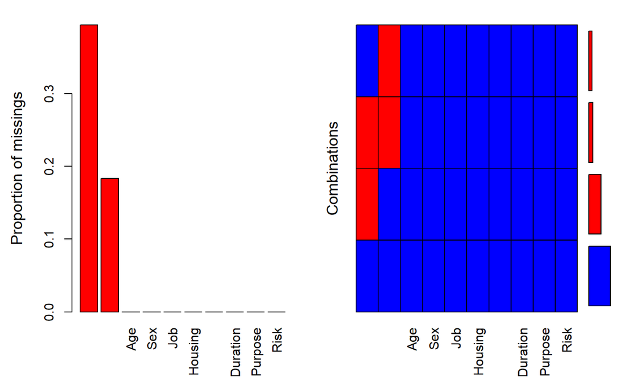

```
##
##  Variables sorted by number of missings:
##          Variable Count
##  Checking.account 0.394
##   Saving.accounts 0.183
##               Age 0.000
##               Sex 0.000
##               Job 0.000
##           Housing 0.000
##     Credit.amount 0.000
##          Duration 0.000
##           Purpose 0.000
##              Risk 0.000
```

```r
aggr(df,labels=names(df),col=c('blue','red'),
     numbrs=T,sortVars=T)
```

As shown above, Saving.accounts & Check.account contain missing values, and red color presents missing part.

### Impute NAs

**missForest** is used to impute missing values particularly in the case of mixed-type data. It can be used to impute **continuous and/or categorical** data including complex interactions and nonlinear relations. It yields an out-of-bag (OOB) imputation error estimate. Moreover, it can be run parallel to save computation time.

```r
df.mis <- df[!complete.cases(df),]
df.train <- df[complete.cases(df),]
set.seed(42)
df.imp <- missForest(xmis = df.mis, xtrue = df.train, maxiter = 10, ntree = 200)
message('Out of Bag error: ', df.imp$OOBerror)
```

```
## Out of Bag error: 00.122854452515469
```

**Save imputation result**

```r
df.nomis <- df
df.nomis[!complete.cases(df.nomis),] <- df.imp$ximp
```

**Saving.account values distribution after imputation:**

```r
table(df.nomis$Saving.accounts)
```

```
##
##     little   moderate quite rich       rich
##        731        116         92         61
```

**Checking.account values distribution after imputation:**

```r
table(df.nomis$Checking.account)
```

```
##
##   little moderate     rich
##      364      482      154
```

- Save cleaned dataset

```r
write.csv(df.nomis,file = 'german_credit_data_rmna.csv',row.names=F)
```

- Summary dataset

```r
summary(df.nomis)
```

```
##       Age            Sex           Job        Housing      Saving.accounts
##  Min.   :19.00   female:310   Min.   :0.000   free:108   little    :731
##  1st Qu.:27.00   male  :690   1st Qu.:2.000   own :713   moderate  :116
##  Median :33.00                Median :2.000   rent:179   quite rich: 92
##  Mean   :35.55                Mean   :1.904              rich      : 61
##  3rd Qu.:42.00                3rd Qu.:2.000
##  Max.   :75.00                Max.   :3.000
##
##  Checking.account Credit.amount      Duration                   Purpose
##  little  :364     Min.   :  250   Min.   : 4.0   car                :337
##  moderate:482     1st Qu.: 1366   1st Qu.:12.0   radio/TV           :280
##  rich    :154     Median : 2320   Median :18.0   furniture/equipment:181
##                   Mean   : 3271   Mean   :20.9   business           : 97
##                   3rd Qu.: 3972   3rd Qu.:24.0   education          : 59
##                   Max.   :18424   Max.   :72.0   repairs            : 22
##                                                  (Other)            : 24
##    Risk
##  bad :300
##  good:700
##
##
##
##
##
```

### Descriptions of cleaned dataset

- Age: (quantitative, in years)
- Sex: (dichotomous: female, male)
- Job: (ordinal: 0 - unskilled and non-resident, 1 - unskilled and resident, 2 - skilled, 3 - highly skilled)
- Housing: (nominal: own, rent, or free)
- Saving.accounts: (ordinal: little, moderate, quite rich, rich) - Status of existing saving account.
- Checking.account: (ordinal: little, moderate, rich) - Status of existing checking account.
- Credit.amount: (quantitative, in D-mark) The maximum amount that the bank is committed to lend.
- Duration: (quantitative, in month) The specified time to pay the credit.
- Purpose: (nominal: car, furniture/equipment, radio/TV, domestic appliances, repairs, education, business, vacation/others) - Reasons to get a loan.
- Risk: (dichotomous : good, bad)

## 2.2 Sanction Loan dataset

### 2.2.1 Data Understanding

### Read data

```r
data = read.csv('train.csv', stringsAsFactors = T)
#data = read.csv(file.choose(), stringsAsFactors = T)
#select needed vars for regression model.
data=subset(data, select=c(Age, Income..USD., Loan.Amount.Request..USD.,
                           Current.Loan.Expenses..USD., Credit.Score,
                           Property.Price, Loan.Sanction.Amount..USD., Type.of.Employment))
#rename vars
names(data) <- c('Age','Income','Loan.Amount.Request','Current.Loan.Expenses','Credit.Score','Property.Price','Loan.Sanction.Amount','Employment.Type')
head(data)
```

```
##   Age  Income Loan.Amount.Request Current.Loan.Expenses Credit.Score
## 1  56 1933.05            72809.58                241.08       809.44
## 2  32 4952.91            46837.47                495.81       780.40
## 3  65  988.19            45593.04                171.95       833.15
## 4  65      NA            80057.92                298.54       832.70
## 5  31 2614.77           113858.89                491.41       745.55
## 6  60 1234.92            34434.72                181.48       684.12
##   Property.Price Loan.Sanction.Amount       Employment.Type
## 1      119933.46             54607.18           Sales staff
## 2       54791.00             37469.98
## 3       72440.58             36474.43
## 4      121441.51             56040.54
## 5      208567.91             74008.28 High skill tech staff
## 6       43146.82             22382.57           Secretaries
```

### See the structure of dataset

```r
str(data)
```

```
## 'data.frame':    30000 obs. of  8 variables:
##  $ Age                  : int  56 32 65 65 31 60 43 45 38 18 ...
##  $ Income               : num  1933 4953 988 NA 2615 ...
##  $ Loan.Amount.Request  : num  72810 46837 45593 80058 113859 ...
##  $ Current.Loan.Expenses: num  241 496 172 299 491 ...
##  $ Credit.Score         : num  809 780 833 833 746 ...
##  $ Property.Price       : num  119933 54791 72441 121442 208568 ...
##  $ Loan.Sanction.Amount : num  54607 37470 36474 56041 74008 ...
##  $ Employment.Type      : Factor w/ 19 levels "","Accountants",..: 16 1 1 1 7 17 10 12 4 10 ...
```

## 2.2.2 Handle missing data

### Check missing values

```r
print(paste('Complete obs.:',sum(complete.cases(data))))
```

```
## [1] "Complete obs.: 23820"
```

- Distribution of NAs (by column):

```r
colSums(is.na(data))
```

```
##                   Age                Income   Loan.Amount.Request
##                     0                  4576                     0
## Current.Loan.Expenses          Credit.Score        Property.Price
##                   172                  1703                     0
##  Loan.Sanction.Amount       Employment.Type
##                   340                     0
```

- Check if any missing value is “” type

```r
colSums(data=="")
```

```
##                   Age                Income   Loan.Amount.Request
##                     0                    NA                     0
## Current.Loan.Expenses          Credit.Score        Property.Price
##                    NA                    NA                     0
##  Loan.Sanction.Amount       Employment.Type
##                    NA                  7270
```

### Visualisation of missing part

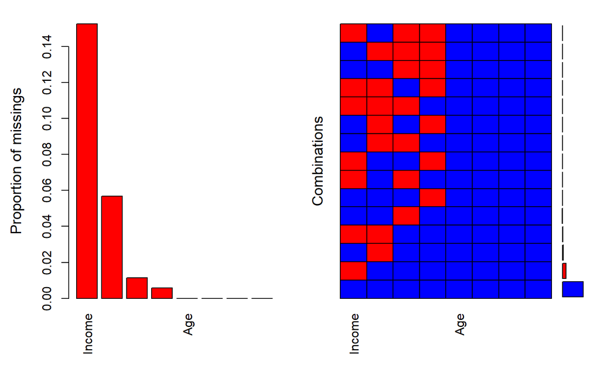

```
##
##  Variables sorted by number of missings:
##               Variable       Count
##                 Income 0.152533333
##           Credit.Score 0.056766667
##   Loan.Sanction.Amount 0.011333333
##  Current.Loan.Expenses 0.005733333
##                    Age 0.000000000
##    Loan.Amount.Request 0.000000000
##         Property.Price 0.000000000
##        Employment.Type 0.000000000
```

```r
aggr(data,labels=names(data),col=c('blue','red'),
     numbrs=T,sortVars=T)
```

As shown above, 4 columns contain missing values, and red color presents missing part.

### impute NAs and solve outliers

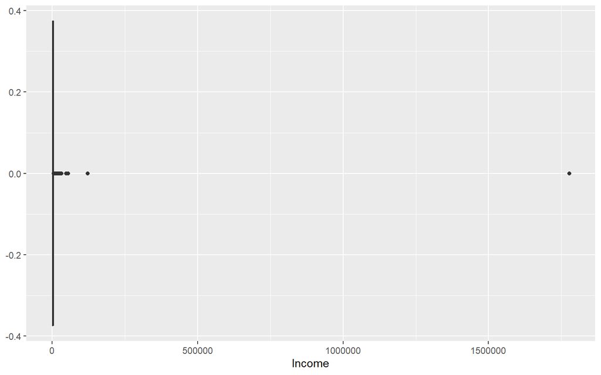

```r
# use group median income of employment type to impute income
new <- ave(data$Income, list(data$Employment.Type), FUN=function(x) median(x, na.rm = TRUE))
# smooth anomaly obs
ggplot(data)+
  geom_boxplot(aes(x=Income))
```

```r
data$Income[is.na(data$Income)] <- new[is.na(data$Income)]
data[data['Income']>120000,'Income']<- median(data[data$Employment.Type==data[data['Income']>120000,'Employment.Type'],'Income'])
```

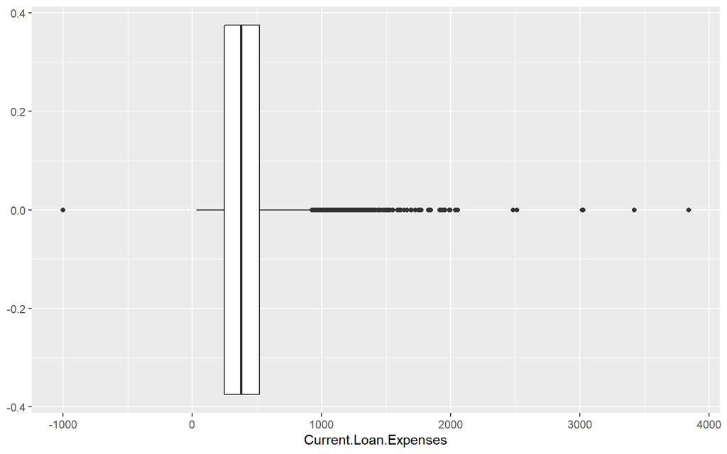

```r
data$Current.Loan.Expenses[is.na(data$Current.Loan.Expenses)] <- median(data$Current.Loan.Expenses, na.rm=TRUE)
ggplot(data)+
  geom_boxplot(aes(x=Current.Loan.Expenses))
```

```r
data[data$Current.Loan.Expenses<0,]$Current.Loan.Expenses <- median(data$Current.Loan.Expenses, na.rm=TRUE)
```

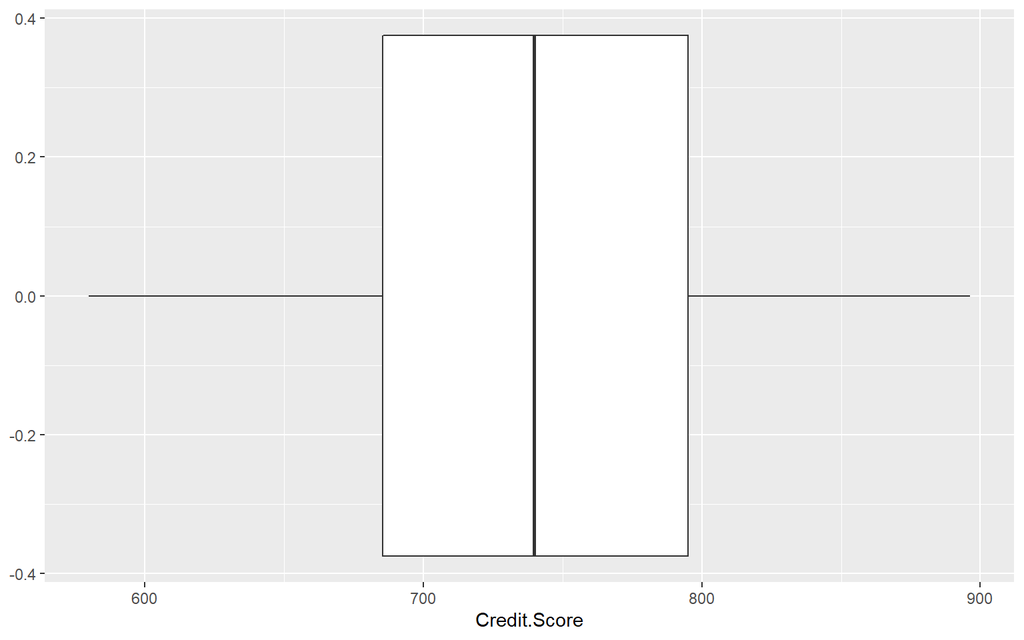

```r
data$Credit.Score[is.na(data$Credit.Score)] <- mean(data$Credit.Score, na.rm=TRUE)
ggplot(data)+
  geom_boxplot(aes(x=Credit.Score))
```

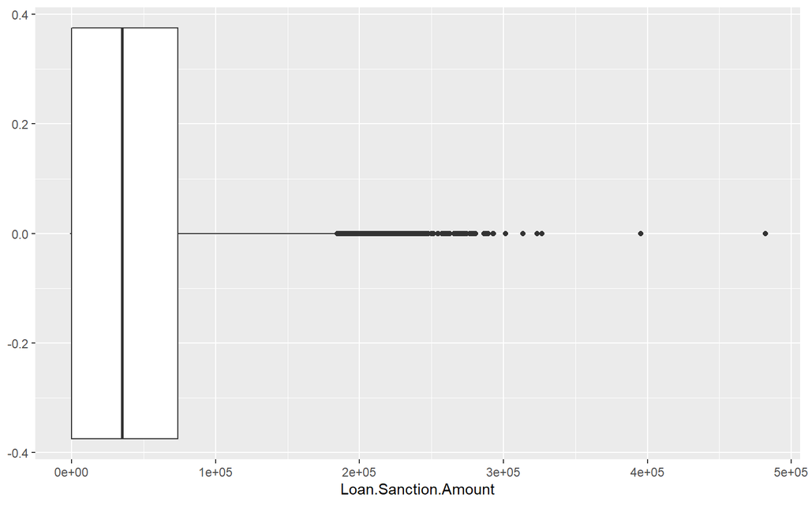

```r
data$Loan.Sanction.Amount[is.na(data$Loan.Sanction.Amount)] <-
median(data$Loan.Sanction.Amount, na.rm=TRUE)
ggplot(data)+
  geom_boxplot(aes(x=Loan.Sanction.Amount))
```

```r
data=subset(data,select = -c(Employment.Type))
```

- Save cleaned dataset

```r
write.csv(data,file = 'train_cleaned.csv',row.names=F)
```

- Summary dataset

```r
summary(data)
```

```
##       Age            Income        Loan.Amount.Request Current.Loan.Expenses
##  Min.   :18.00   Min.   :  377.7   Min.   :  6048      Min.   :  33.76
##  1st Qu.:25.00   1st Qu.: 1738.8   1st Qu.: 41178      1st Qu.: 252.14
##  Median :40.00   Median : 2165.9   Median : 75128      Median : 375.20
##  Mean   :40.09   Mean   : 2510.5   Mean   : 88826      Mean   : 408.90
##  3rd Qu.:55.00   3rd Qu.: 2959.3   3rd Qu.:119965      3rd Qu.: 520.10
##  Max.   :65.00   Max.   :54653.8   Max.   :621498      Max.   :3840.88
##   Credit.Score   Property.Price    Loan.Sanction.Amount
##  Min.   :580.0   Min.   :   -999   Min.   :  -999
##  1st Qu.:685.4   1st Qu.:  60572   1st Qu.:     0
##  Median :739.9   Median : 109994   Median : 35209
##  Mean   :739.9   Mean   : 131760   Mean   : 47508
##  3rd Qu.:795.1   3rd Qu.: 178881   3rd Qu.: 73764
##  Max.   :896.3   Max.   :1077967   Max.   :481907
```

# 3 Exploratory Data Analysis

## 3.1 General Correlation

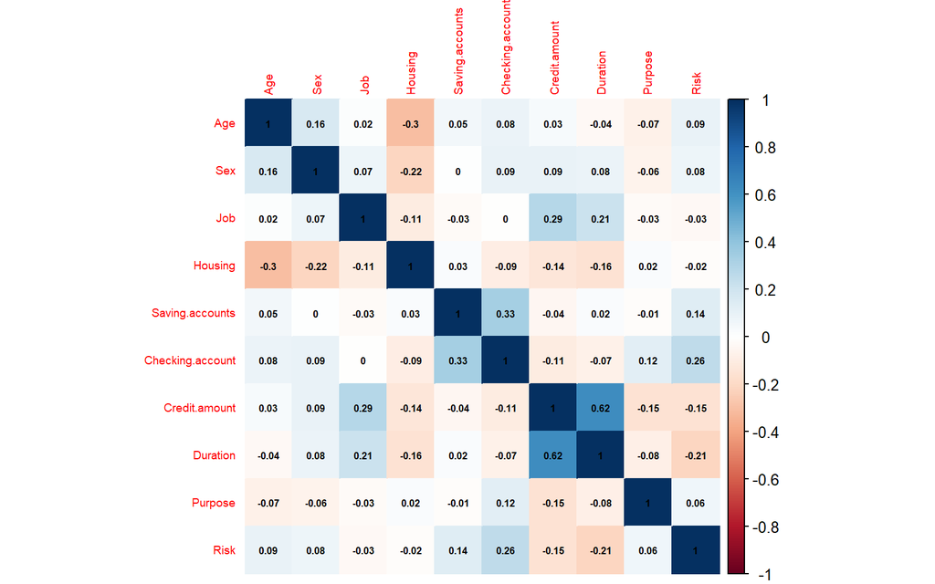

```r
df.nomis_temp <- df.nomis
df.nomis_temp$Age <- as.numeric(df.nomis_temp$Age)
df.nomis_temp$Sex <- as.numeric(df.nomis_temp$Sex)
df.nomis_temp$Job <- as.numeric(df.nomis_temp$Job)
df.nomis_temp$Housing <- as.numeric(df.nomis_temp$Housing)
df.nomis_temp$Saving.accounts <- as.numeric(df.nomis_temp$Saving.accounts)
df.nomis_temp$Checking.account <- as.numeric(df.nomis_temp$Checking.account)
df.nomis_temp$Credit.amount <- as.numeric(df.nomis_temp$Credit.amount)
df.nomis_temp$Duration <- as.numeric(df.nomis_temp$Duration)
df.nomis_temp$Purpose <- as.numeric(df.nomis_temp$Purpose)
df.nomis_temp$Risk <- as.numeric(df.nomis_temp$Risk)

corrplot(cor(df.nomis_temp),tl.cex = 0.6, method = "color",  addCoef.col="black", number.cex = 0.5)
```

## 3.2 Variables Distribution

### 3.2.1 Continuous Variables Distribution

```r
summary(df.nomis[,c(1,7,8)])
```

```
##       Age        Credit.amount      Duration
##  Min.   :19.00   Min.   :  250   Min.   : 4.0
##  1st Qu.:27.00   1st Qu.: 1366   1st Qu.:12.0
##  Median :33.00   Median : 2320   Median :18.0
##  Mean   :35.55   Mean   : 3271   Mean   :20.9
##  3rd Qu.:42.00   3rd Qu.: 3972   3rd Qu.:24.0
##  Max.   :75.00   Max.   :18424   Max.   :72.0
```

```r
par(mfrow = c(2,2))
```

#### Age, Credit.amount, Duration

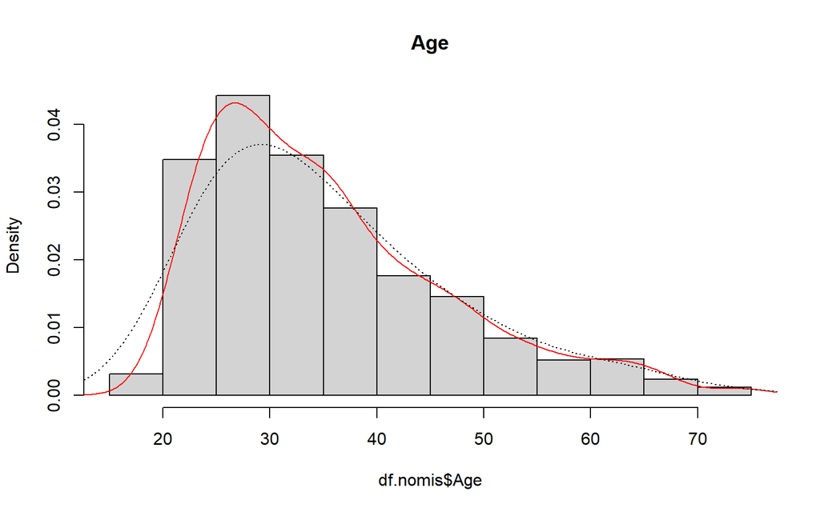

```r
hist(df.nomis$Age, main = "Age", prob = TRUE)
lines(density(df.nomis$Age),col="red")
lines(density(df.nomis$Age, adjust=2), lty="dotted")
```

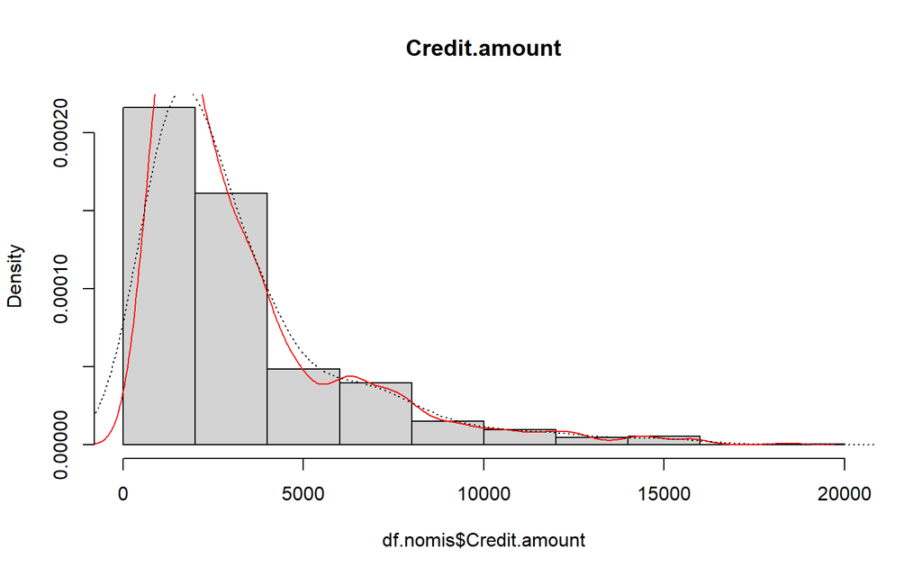

```r
hist(df.nomis$Credit.amount, main = "Credit.amount", prob = TRUE)
lines(density(df.nomis$Credit.amount),col="red")
lines(density(df.nomis$Credit.amount, adjust=2), lty="dotted")
```

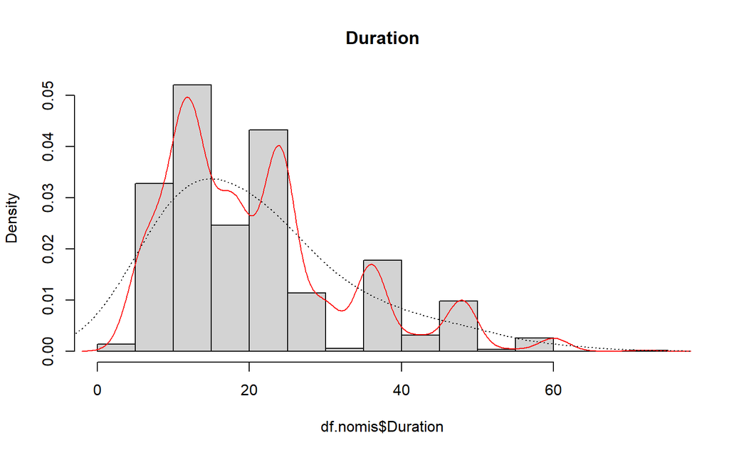

```r
hist(df.nomis$Duration, main = "Duration", prob = TRUE)
lines(density(df.nomis$Duration),col="red")
lines(density(df.nomis$Duration, adjust=3), lty="dotted")
```

### 3.2.2 Discrete Variables Distribution

```r
tabular(Sex~1*(n=1 + Percent("col")),data = df.nomis)
```

| Sex | All n | All n Percent |
| --- | --- | --- |
| female | 310 | 31 |
| male | 690 | 69 |

```r
tabular(Housing~1*(n=1 + Percent("col")),data = df.nomis)
```

| Housing | All n | All n Percent |
| --- | --- | --- |
| free | 108 | 10.8 |
| own | 713 | 71.3 |
| rent | 179 | 17.9 |

```r
tabular(Purpose~1*(n=1 + Percent("col")),data = df.nomis)
```

| Purpose | All n | All n Percent |
| --- | --- | --- |
| business | 97 | 9.7 |
| car | 337 | 33.7 |
| domestic appliances | 12 | 1.2 |
| education | 59 | 5.9 |
| furniture/equipment | 181 | 18.1 |
| radio/TV | 280 | 28.0 |
| repairs | 22 | 2.2 |
| vacation/others | 12 | 1.2 |

```r
tabular(Risk~1*(n=1 + Percent("col")),data = df.nomis)
```

| Risk | All n | All n Percent |
| --- | --- | --- |
| bad | 300 | 30 |
| good | 700 | 70 |

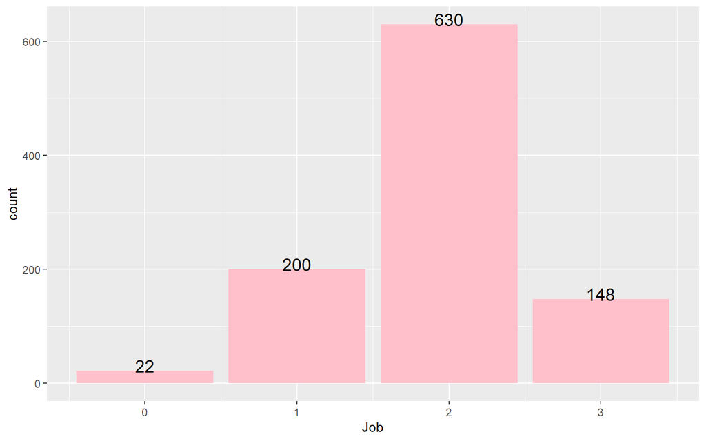

```r
ggplot(data = df.nomis, aes(Job), main = "Job") + geom_bar(fill="pink") +
geom_text(aes(label=..count..),stat="count", vjust= 0.1, cex =5)
```

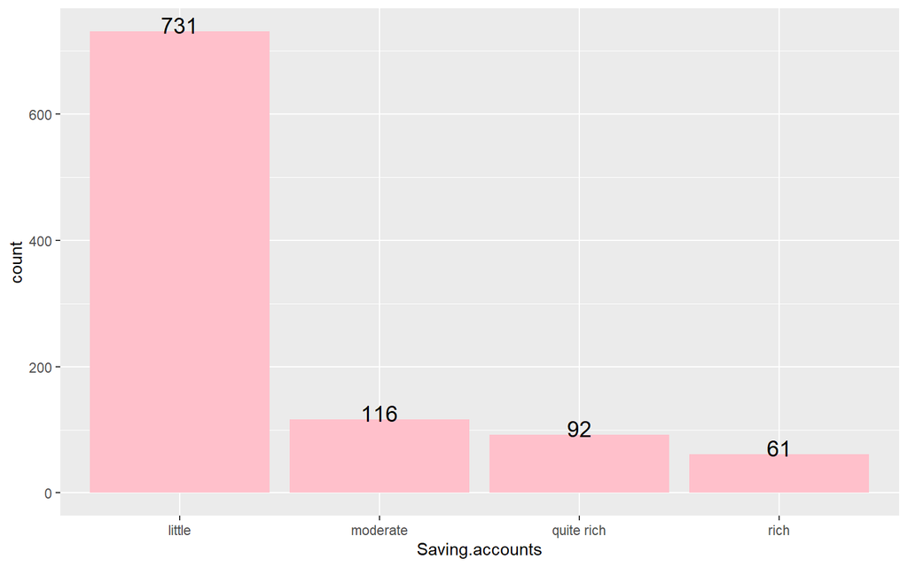

```r
ggplot(data = df.nomis, aes(Saving.accounts), main = "Saving.accounts") + geom_bar(fill="pink") +
geom_text(aes(label=..count..),stat="count", vjust= 0.1, cex =5)
```

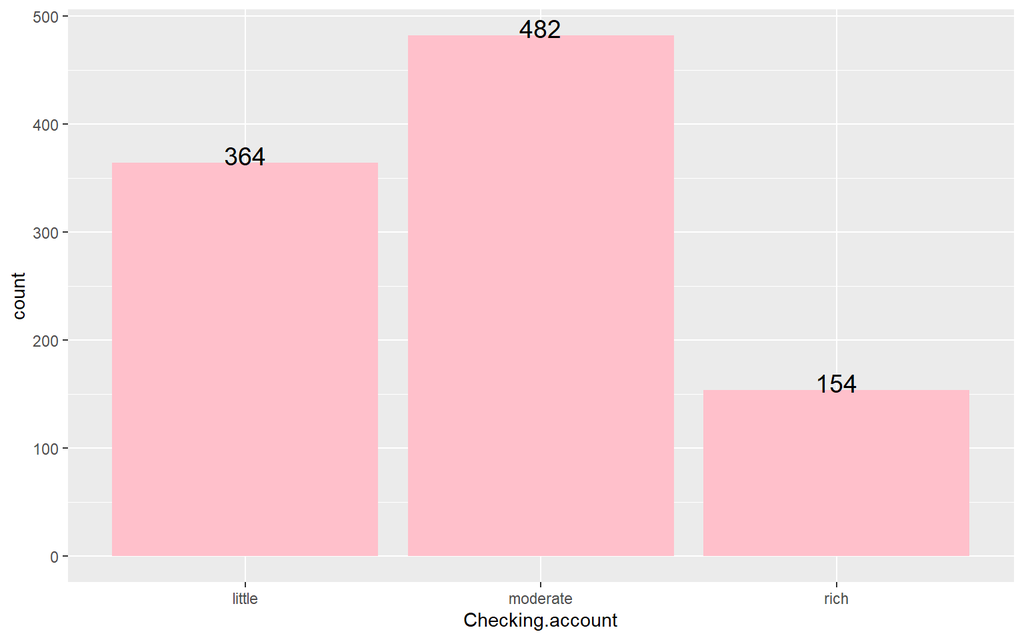

```r
ggplot(data = df.nomis, aes(Checking.account), main = "Checking.account") + geom_bar(fill="pink") + geom_text(aes(label=..count..),stat="count", vjust= 0.1, cex =5)
```

## 3.3 Correlations with Credit Risk

### 3.3.1 Age

#### Age and Risk

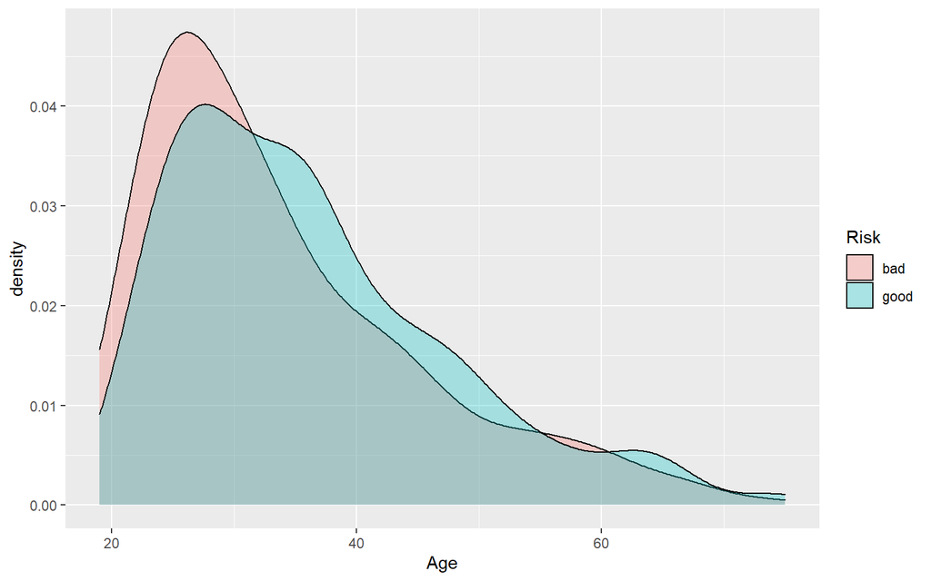

```r
ggplot(df.nomis) + geom_density(aes(Age,fill= Risk),alpha= 0.3)
```

#### Age, Risk and Sex

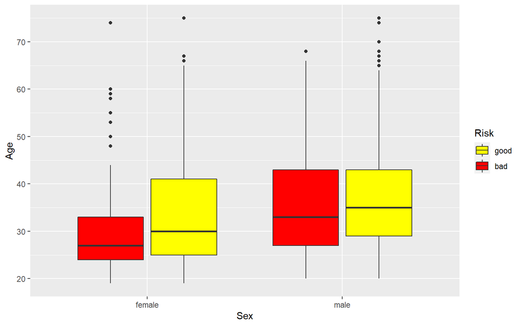

```r
df.nomis %>% ggplot(aes(Sex,Age, fill=Risk)) + geom_boxplot() + scale_y_continuous(breaks = seq(0,100,10))+ scale_fill_manual(breaks = df.nomis$Risk,
values = c("yellow", "red"))
```

#### Age, Risk and Housing

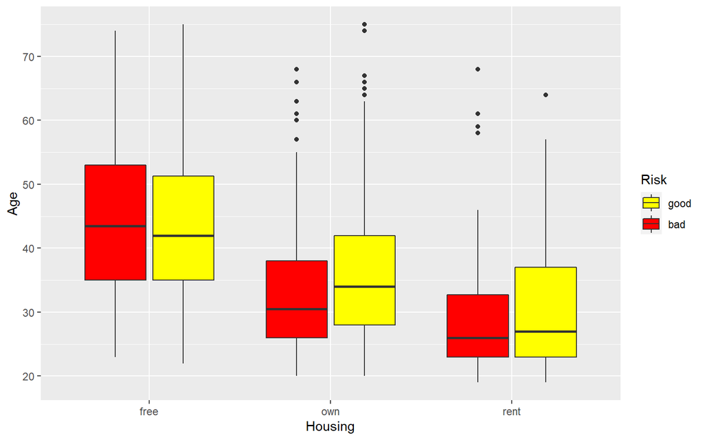

```r
df.nomis %>% ggplot(aes(Housing,Age, fill=Risk)) + geom_boxplot() + scale_y_continuous(breaks = seq(0,100,10))+ scale_fill_manual(breaks = df.nomis$Risk,
values = c("yellow", "red"))
```

### 3.3.2 Sex

#### Sex and Risk

```r
tabular(Risk*Sex~1*(n=1 + Percent("col")), data=df.nomis)
```

| Risk | Sex | All n | All n Percent |
| --- | --- | --- | --- |
| bad | female | 109 | 10.9 |
|  | male | 191 | 19.1 |
| good | female | 201 | 20.1 |
|  | male | 499 | 49.9 |

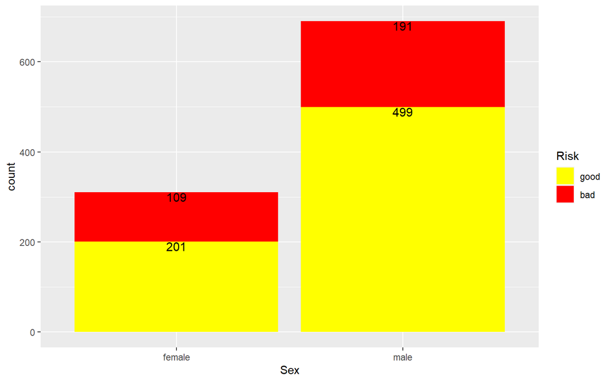

```r
df.nomis %>% ggplot(aes(Sex,fill=Risk)) +geom_bar() + geom_text(stat="count", aes(label=..count..,group=Risk),
position = "stack",vjust=1, cex = 4)+ scale_fill_manual(breaks = df.nomis$Risk,
values = c("yellow", "red"))
```

#### Sex, Risk and Housing

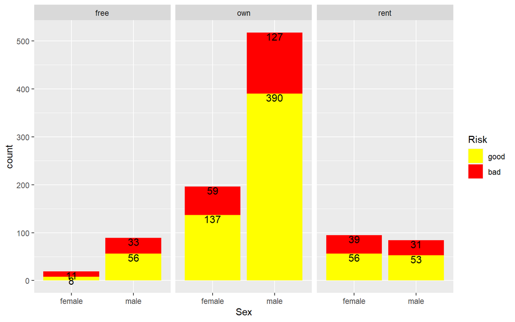

```r
ggplot(aes(x= Sex,fill=Risk),data = df.nomis) +geom_bar() +
geom_text(stat="count", aes(label=..count..,group=Risk), position = "stack",vjust=1, cex =4) + facet_wrap(~Housing)+ scale_fill_manual(breaks = df.nomis$Risk,
values = c("yellow", "red"))
```

### 3.3.3 Job

#### Job and Risk

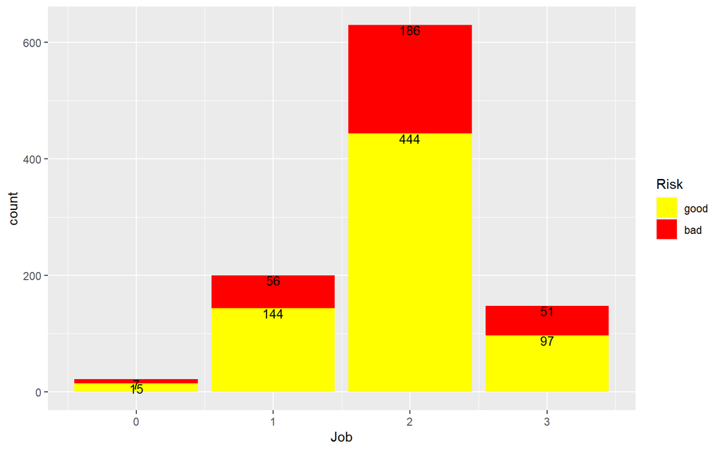

```r
df.nomis %>% ggplot(aes(x=Job, fill = Risk)) + geom_bar() + geom_text(stat= "count", aes(label=..count.., group = Risk),cex=3.5, vjust=1, position = "stack")+ scale_fill_manual(breaks = df.nomis$Risk,
values = c("yellow", "red"))
```

#### Job, Housing and Risk

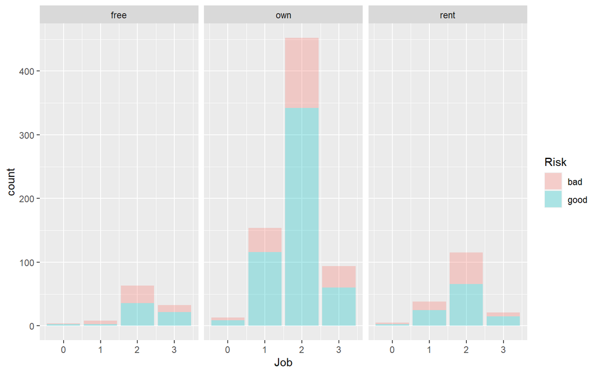

```r
df.nomis %>% ggplot(aes(Job, fill= Risk)) + geom_bar(alpha= 0.3) + facet_wrap(~Housing)
```

#### Job, Credit.amount and Risk

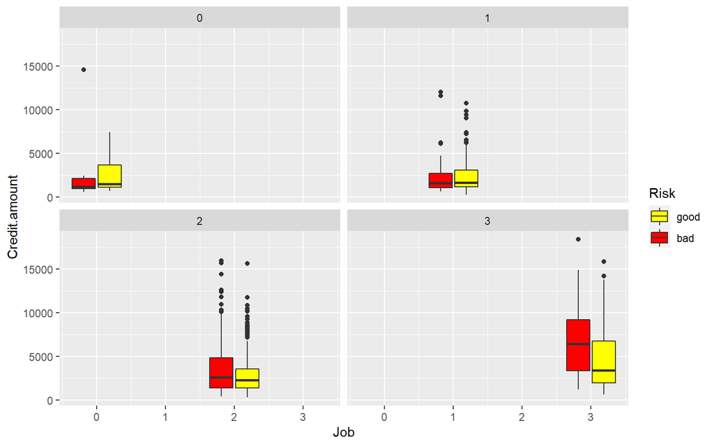

```r
df.nomis %>%  ggplot(aes(Job,Credit.amount, fill=Risk)) + geom_boxplot() + facet_wrap(~Job)+ scale_fill_manual(breaks = df.nomis$Risk,
values = c("yellow", "red"))
```

#### Job, Duration and Risk

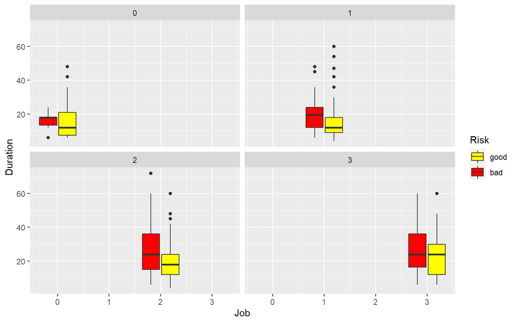

```r
df.nomis %>%  ggplot(aes(Job,Duration, fill=Risk)) + geom_boxplot() + facet_wrap(~Job)+ scale_fill_manual(breaks = df.nomis$Risk,
values = c("yellow", "red"))
```

### 3.3.4 Housing

#### Housing and Risk

```r
tabular(Risk*Housing~1*(n=1 + Percent("col")), data=df.nomis)
```

| Risk | Housing | All n | All n Percent |
| --- | --- | --- | --- |
| bad | free | 44 | 4.4 |
|  | own | 186 | 18.6 |
|  | rent | 70 | 7.0 |
| good | free | 64 | 6.4 |
|  | own | 527 | 52.7 |
|  | rent | 109 | 10.9 |

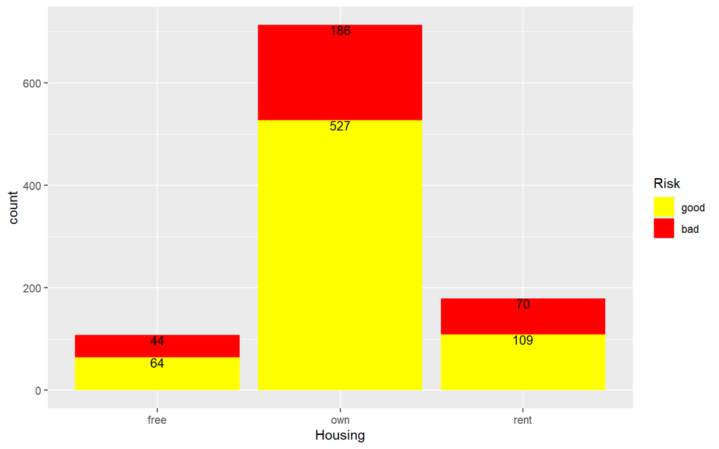

```r
df.nomis %>% ggplot(aes(x= Housing, fill = Risk)) + geom_bar() + geom_text(stat= "count", aes(label=..count.., group = Risk),cex=3.5, vjust=1, position = "stack")+ scale_fill_manual(breaks = df.nomis$Risk,
values = c("yellow", "red"))
```

#### Housing, Duration and Risk

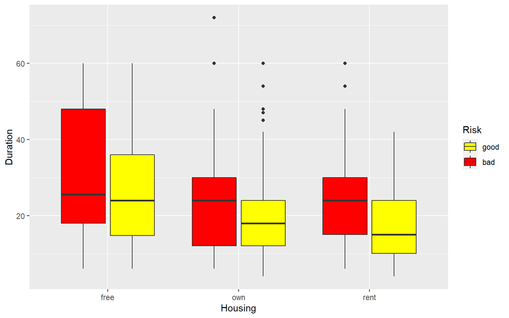

```r
df.nomis %>% ggplot(aes(Housing, Duration, fill=Risk)) + geom_boxplot() + scale_fill_manual(breaks = df.nomis$Risk,
values = c("yellow", "red"))
```

#### Housing, Credit.amount and risk

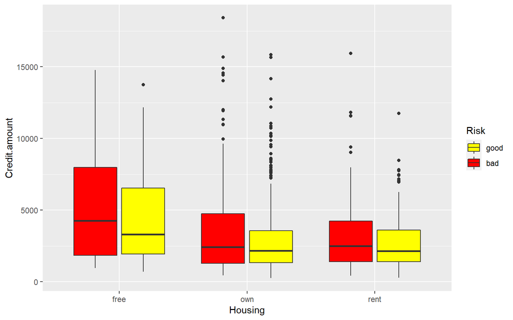

```r
df.nomis %>% ggplot(aes(Housing, Credit.amount, fill=Risk)) + geom_boxplot()+ scale_fill_manual(breaks = df.nomis$Risk,
values = c("yellow", "red"))
```

### 3.3.5 Savings.accounts

#### Saving.accounts and Risk

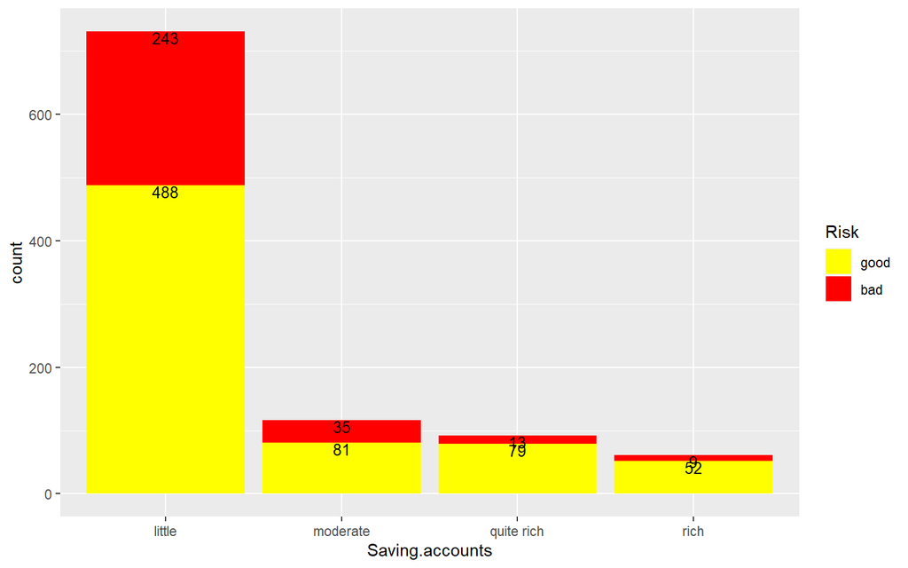

```r
df.nomis %>% ggplot(aes(x=Saving.accounts, fill = Risk)) + geom_bar() + geom_text(stat= "count", aes(label=..count.., group = Risk),cex=3.5, vjust=1, position = "stack")+ scale_fill_manual(breaks = df.nomis$Risk,
values = c("yellow", "red"))
```

#### Saving.accounts, Credit.amount and Risk

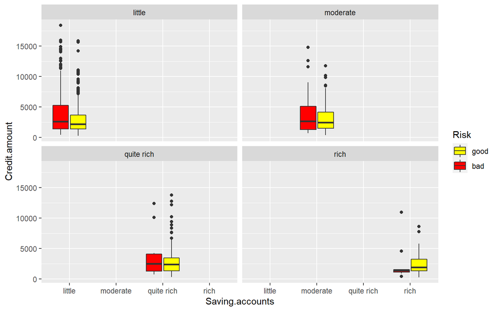

```r
df.nomis %>%  ggplot(aes(Saving.accounts,Credit.amount, fill=Risk)) + geom_boxplot() + facet_wrap(~Saving.accounts)+ scale_fill_manual(breaks = df.nomis$Risk,
values = c("yellow", "red"))
```

### 3.3.6 Checking.account

#### Checking.account and Risk

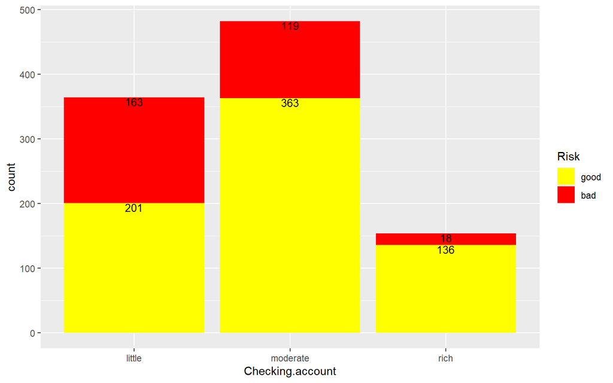

```r
df.nomis %>% ggplot(aes(x=Checking.account, fill = Risk)) + geom_bar() + geom_text(stat= "count", aes(label=..count.., group = Risk),cex=3.5, vjust=1, position = "stack")+ scale_fill_manual(breaks = df.nomis$Risk,
values = c("yellow", "red"))
```

### 3.3.7 Credit.amount

#### Credit.amount and Risk

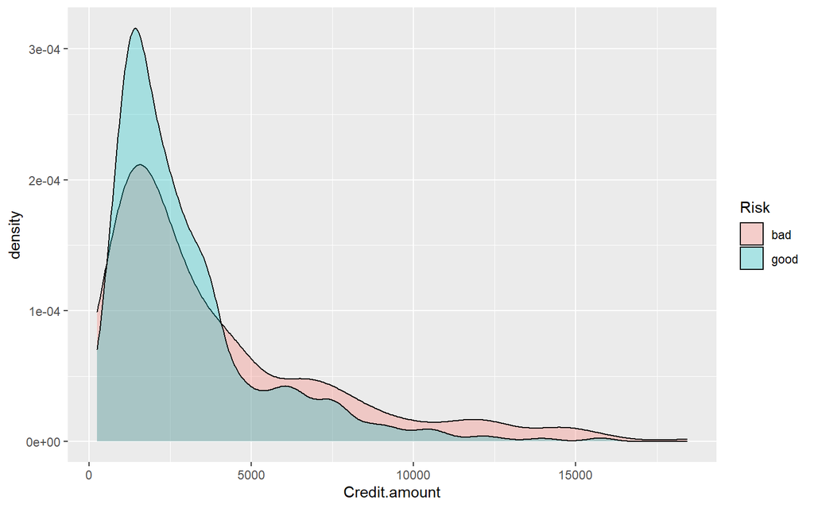

```r
ggplot(df.nomis) + geom_density(aes(Credit.amount,fill= Risk),alpha= 0.3)
```

#### Credit.amount and Duration

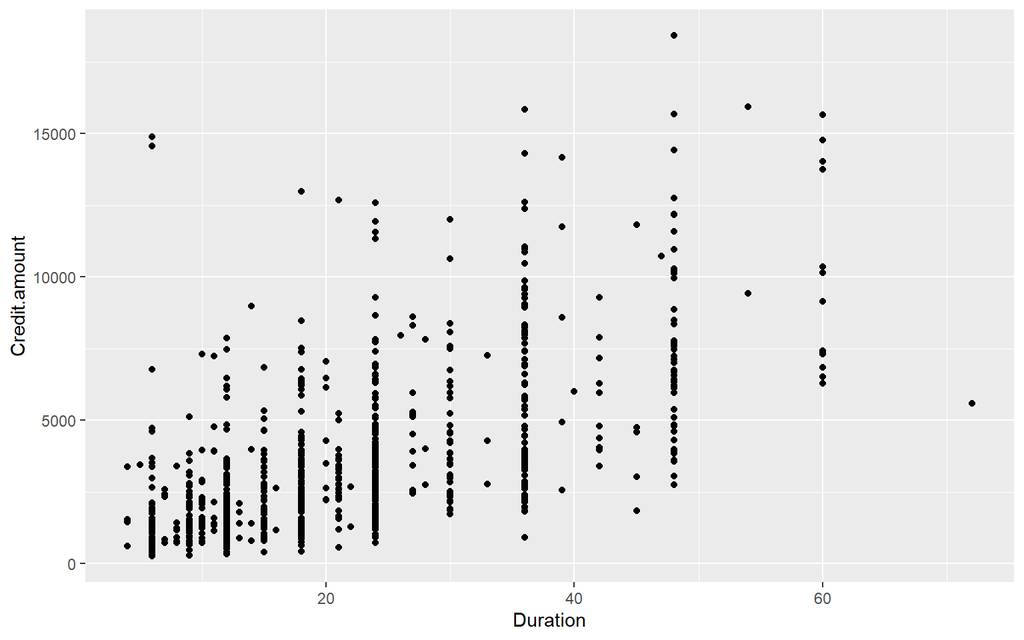

```r
df.nomis %>% ggplot(aes(Duration, Credit.amount)) + geom_point()
```

#### Credit.amount and Purpose

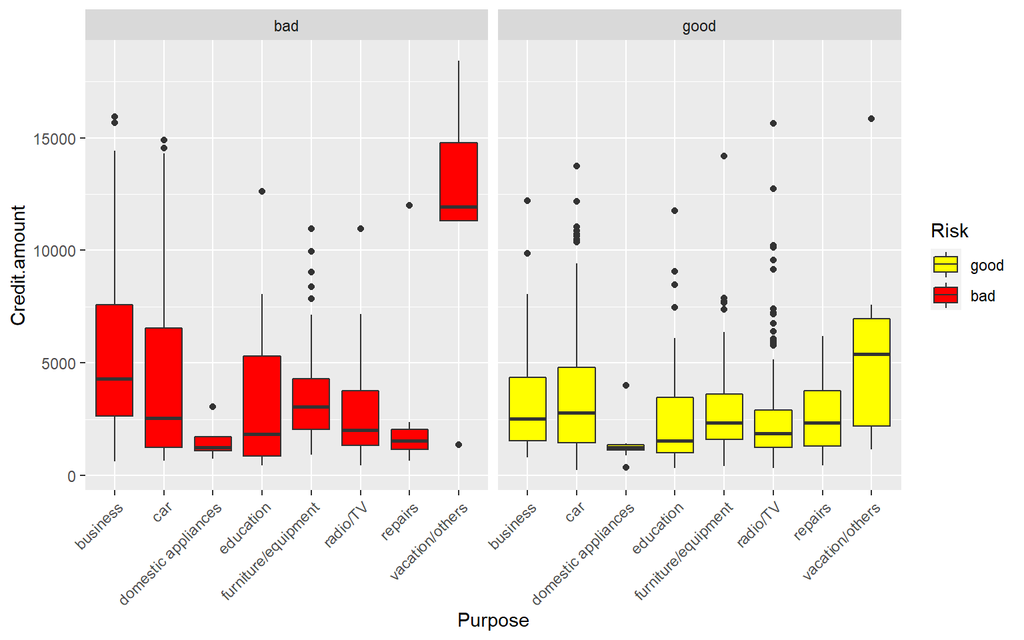

```r
df.nomis %>% ggplot(aes(Purpose, Credit.amount,fill=Risk)) + geom_boxplot() +facet_wrap(~Risk)+ theme(axis.text.x  = element_text(angle = 45, hjust = 1))+ scale_fill_manual(breaks = df.nomis$Risk,
values = c("yellow", "red"))
```